# 統計計算與模擬期末報告

105354003林芃彣

June, 22, 2017

## 主題：賭場遊戲

- 玩法簡單且直觀，是最適合新手的遊戲之一
- **玩法**：這是一種相對簡單的撲克牌遊戲，玩家下注，玩家獲發一張牌後，莊家為自己發一張牌，作比較點數，點數大的為勝方，撲克牌的花色與牌的大小無關，這個遊戲通常會使用六副撲克牌，牌的大小次序依次為A、K、Q、J、10、9、8、7、6、5、4、3、2，由於牌的花色於此遊戲中無效，故當莊家和玩家的點數相同時，玩家可作以下兩個選擇：
  - 投降 (Surrender) ：玩家可取回下注金額的一半，也就是輸掉一半的賭注
  - 進入賭場戰爭 (Going to War) ：玩家需額外再加上相等於原注的金額進入賭場戰爭，然後莊荷會消去三張牌，再發牌給玩家，及後再消去三張牌，發牌給自己，如果莊家點數較大，玩家會輸掉原注和額外加注。如玩家點數較大，則贏取與額外加注相等的金額。如兩者點數再次相同，玩家則可贏取原注與額外加注的兩份賠彩。
- 由以上規則可以看出，這是賭場優勢非常大的一種賭博遊戲，道理很簡單，牌相同時，賭客選擇投降，自動輸掉一半賭注，選擇進入賭場戰爭，贏的時候只贏一倍，輸的時候則輸兩倍，雖說牌再次相同時贏兩倍的原始賭注，但賭客與發牌員兩張牌都相同的機率遠小於1%，所以這個遊戲的賭場優勢 (House Advantage) 是頗高的，一般都超過2%。
- 但作為一種娛樂遊戲，賭場戰爭是有其吸引人的地方，特別對於初進賭場的年輕人，想拿十幾塊錢碰碰運氣，不妨玩一下這個遊戲，但時間不可太久，玩上幾手，輸贏都走，很可能贏錢。

## 動機與目的

- **動機**：想做跟賭場遊戲有關的模擬，像是21點是賭場裡最常見也算有名的遊戲，但應該有其他同學做這個題目，而且也相當多人有做過類似的模擬，於是去找尋其他的遊戲，後來發現了這個賭場遊戲，是之前沒有聽過賭場裡會有的遊戲，而且概念相當簡單，因次想以此當作主題。
- **目的**：這是一個在賭場裡很適合新手的遊戲，而我也從來沒去進到賭場下注過，所以假想初入賭場的我想找到可以在這個遊戲運行的一套規則，而賭場遊戲基本上都是有具有賭場優勢的，雖然這個遊戲看起來就是運氣問題，但能不能找到一個停損點，或是贏到多少錢的時候就收手。

## 研究方法與假設

- 設計一套自己喜歡的下注方式，具有規則也方便模擬，真正在賭場下注時也適合有一套規律的運作，
- 找到一個停損點，在現實賭場時，當運氣不好確實有可能一直輸錢，那要在什麼時候收手讓自己冷靜一下

**假設**

- 賭金：每注10元
- 六副撲克牌，共312張牌，

#### 1.模擬只比大或小贏的機率是不是一半一半

```r
draw <- function(x){
  a <- sample(x, 1)
  s <- sum(x==a)-1
  x <- c(x[x!=a], rep(a,s))
  return(x)
}

x <- rep(c(2:14),6*4)
length(x)
```

```
## [1] 312
```

```r
money = 1000
n <- 50
k <- vector(length = n)
money_n <- vector(length = n)
e = NULL
for (j in 1:n) {
  # player
  a <- sample(x, 1)
  s <- sum(x==a)-1
  x <- c(x[x!=a], rep(a,s))
  # 莊
  b <- sample(x, 1)
  s <- sum(x==a)-1
  x <- c(x[x!=a], rep(a,s))

  if (a>b){ k[j]=1 } else if (a==b) {k[j]=0} else  k[j]=-1
  if (k[j] != 0 ) { money <- money+k[j]*10 }
else  {
  for (i in 1:3) {
    x<- draw(x)
  }
  # player
  a <- sample(x, 1)
  s <- sum(x==a)-1
  x <- c(x[x!=a], rep(a,s))
  for (i in 1:3) {
    x<- draw(x)
  }
  # 莊
  b <- sample(x, 1)
  s <- sum(x==a)-1
  x <- c(x[x!=a], rep(a,s))
 if (a>b){ g=1 } else if (a==b) {g=4} else  g=-2
  money <- money+g*10
  e  <- c(e,g)
  }
  money_n[j] <- money
}

k
```

```
##  [1]  1  1  1 -1 -1 -1 -1 -1 -1 -1  1  0 -1 -1 -1 -1 -1  1 -1 -1 -1  0 -1
## [24] -1  1  1  0 -1 -1  1  1  1  1  1 -1 -1  1 -1 -1  1  1  1 -1  1 -1 -1
## [47] -1 -1 -1  1
```

```r
table(k)
```

```
## k
## -1  0  1
## 29  3 18
```

```r
e
```

```
## [1] -2 -2 -2
```

```r
money
```

```
## [1] 830
```

```r
money_n
```

```
##  [1] 1010 1020 1030 1020 1010 1000  990  980  970  960  970  950  940  930
## [15]  920  910  900  910  900  890  880  860  850  840  850  860  840  830
## [29]  820  830  840  850  860  870  860  850  860  850  840  850  860  870
## [43]  860  870  860  850  840  830  820  830
```

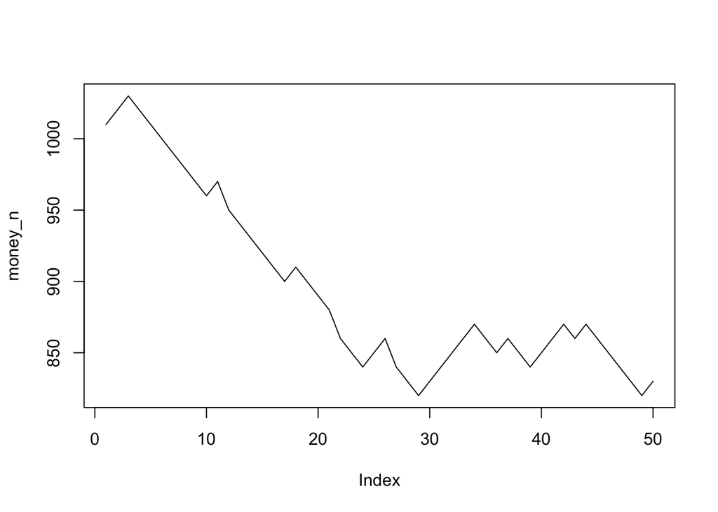

```r
plot(money_n, type = "l")
```